# Praca domowa 3

Martyna Majchrzak

9 11 2019

## Oryginalny wykres

Dane oraz oba wykresy pochodzą ze strony: https://www.cityrating.com/crime-statistics/hawaii/honolulu.html

Wykresy przedstawiają liczbę wystąpień różnego rodzaju przestępstw w Honululu z podziałem na dwie kategorie - jeden w 2016, a jeden z przewidywaniami na 2019.

Błedy:

- Zastosowanie trapezów i trójkatóW utrudnia odczyt wielkosci pól reprezentujących dane
- w dwóch wykresach skale nie są takie same, przez co np. wartośc dla Robbery wygląda na większą od Burglary (ma ponad dwa razy większe pole), mimo że przedstawiona wartość jest ponad 4 krotnie mniejsza
- wartości nie są uporządkowane rosnąco w układzie góra-dół
- zastosowanie identycznej palety (nic swoją drogą nie oznaczających) kolorów na wykresach sugeruje jakąś zależność między danymi reprezentowanymi tym samym kolorem, której zwyczajnie tam nie ma.
- brakuje opisu osi (co oznaczają te liczby?)

## Wykres 1

Zaprezentujemy dane z obu wykresów na dwóch wykresach słupkowych, obok siebie.

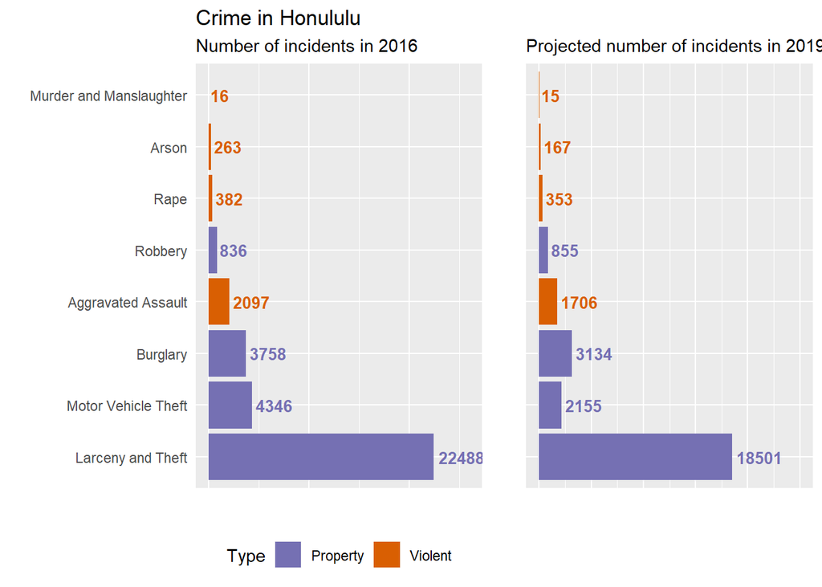

```r
barplot2016<-ggplot(honolulu, aes(x=Crime, y=Incidents2016, fill=Type))+
  geom_col()+
  coord_flip()+
  scale_x_discrete(limits = order)+
  geom_text(label=honolulu$Incidents2016, hjust=-0.1, aes(col=Type), fontface="bold", size=3.5)+
  ylim(0, 26000)+
  labs(title="Crime in Honululu", x="", y="", subtitle ="Number of incidents in 2016")+
  theme(axis.text.x=element_blank(),
        axis.ticks.x=element_blank(),
        axis.ticks.y=element_blank(),
        legend.position = "bottom")+
  scale_fill_manual(labels = c("Property", "Violent"),
                     values = c("Property"="#7570b3", "Violent"="#d95f02"))+
  scale_color_manual(labels = c("Property", "Violent"),
                     values = c("Property"="#7570b3", "Violent"="#d95f02"))
barplot2019<-ggplot(honolulu, aes(x=Crime, y=Incidents2019, fill=Type))+
  geom_col()+
  coord_flip()+
  scale_x_discrete(limits = order)+
  geom_text(label=honolulu$Incidents2019, hjust=-0.1, aes(col=Type), fontface="bold", size=3.5)+
  ylim(0, 25000)+
  labs(title="", x="", y="", subtitle="Projected number of incidents in 2019")+
  theme(axis.text.x=element_blank(),
        axis.ticks.x=element_blank(),
        axis.text.y=element_blank(),
        axis.ticks.y=element_blank(),
        legend.position = "none")+
  scale_fill_manual(labels = c("Property", "Violent"),
                     values = c("Property"="#7570b3", "Violent"="#d95f02"))+
  scale_color_manual(labels = c("Property", "Violent"),
                     values = c("Property"="#7570b3", "Violent"="#d95f02"))
barplot2016+barplot2019
```

Dzięki zmianie geometrii różnice między wartościami są bardziej przejrzyste, a podział na kategorie przestępstw został zaznaczony kolorem.

## Wykres 2

Proponuję też rozwiązanie bardziej pokazujące różnice między wartościami (spadki/wzrosty) z użyciem slope chartu. Niestety ze wzgledu na olbrzymie różnice w liczbie wystąpień pomijam dane o kradzieżach.

```r
honolulu<-slice(honolulu, 2:8)
p1<-ggplot(honolulu) +
  geom_segment(aes(x=1, xend=2, y=Incidents2016, yend=Incidents2019), size=.75, show.legend=F)+
  geom_point(aes(x=1, y=Incidents2016, colour=Type), size=4)+
  geom_point(aes(x=2, y=Incidents2019, colour=Type), size=4)+
  geom_vline(xintercept=1, linetype="dashed", size=.1) +
  geom_vline(xintercept=2, linetype="dashed", size=.1) +
  scale_color_manual(labels = c("Property", "Violent"),
                     values = c("Property"="#7570b3", "Violent"="#d95f02"))+
  labs(title="Honolulu - number of commited crime incidents", x="", y="")+
  xlim(-1, 4) +
  ylim(0,(1.1*(max(honolulu$Incidents2016, honolulu$Incidents2019))))+
  geom_text(label=paste(honolulu$Crime, honolulu$Incidents2016, sep=", "), aes(y=Incidents2016, x=rep(0.9, NROW(honolulu))), hjust=1, size=2.1)+
  geom_text(label=paste(honolulu$Crime, honolulu$Incidents2019, sep=", "), aes(y=Incidents2019, x=rep(2.1, NROW(honolulu))), hjust=0, size=2.1)+
  geom_text(label="2016", x=1, y=1.1*(max(honolulu$Incidents2016, honolulu$Incidents2019)), hjust=1.2, size=3.5)+
  geom_text(label="2019 (Projected)", x=2, y=1.1*(max(honolulu$Incidents2016, honolulu$Incidents2019)), hjust=-0.2, size=3.5)+
  theme(panel.background = element_blank(),
        panel.grid = element_blank(),
        axis.ticks = element_blank(),
        axis.text.x = element_blank(),
        panel.border = element_blank(),
        plot.margin = unit(c(1,2,1,2), "cm"),
        axis.text.y=element_blank(),
        axis.ticks.y=element_blank(),
        legend.position="bottom",
        plot.title = element_text(hjust = 0.5))

library(plotly)
ggplotly(p1)
```

[interactive chart not shown]